# Chapter 13 Generalized Linear Models

## Generalized additive models

The shape of the relationship between y and a continuous variable x is specified by non-parametric smoothers, not specified by some explicit functional form.

## Offset

A component of a linear predictor that is known in advance from theory, mechanistic model, and thus requires no parameter to be estimated from the data, then `offset` is useful, see examples below.

Example: It’s already known that $v = \frac{g^2}{4\pi}h$, and $log(v) = log(\frac{1}{4\pi} + 2log(g) + log(h)$, that is to say, the coefficients of the intercept, $log(g)$ and $log(h)$ are already known.

```r
# offset
data <- read.delim("timber.txt")
attach(data)
names(data)
```

```
## [1] "volume" "girth"  "height"
```

```r
# rescale the girth to be consistent with other vairables
girth <- girth/100

# fit model without offset
model1 <- glm(log(volume) ~ log(girth) + log(height))
summary(model1)
```

```
##
## Call:
## glm(formula = log(volume) ~ log(girth) + log(height))
##
## Deviance Residuals:
##       Min         1Q     Median         3Q        Max
## -0.168619  -0.048504   0.002509   0.063703   0.129248
##
## Coefficients:
##             Estimate Std. Error t value Pr(>|t|)
## (Intercept) -2.89938    0.63767  -4.547 9.56e-05 ***
## log(girth)   1.98267    0.07503  26.426  < 2e-16 ***
## log(height)  1.11714    0.20448   5.463 7.83e-06 ***
## ---
## Signif. codes:  0 '***' 0.001 '**' 0.01 '*' 0.05 '.' 0.1 ' ' 1
##
## (Dispersion parameter for gaussian family taken to be 0.006626731)
##
##     Null deviance: 8.30893  on 30  degrees of freedom
## Residual deviance: 0.18555  on 28  degrees of freedom
## AIC: -62.697
##
## Number of Fisher Scoring iterations: 2
```

```r
# coefficients close to theoretical ones but not the same


# specify the slope for log(h) to be 1
model2 <- glm(log(volume) ~ log(girth) + offset(log(height)))
summary(model2)
```

```
##
## Call:
## glm(formula = log(volume) ~ log(girth) + offset(log(height)))
##
## Deviance Residuals:
##       Min         1Q     Median         3Q        Max
## -0.168111  -0.047843  -0.006059   0.065681   0.137213
##
## Coefficients:
##             Estimate Std. Error t value Pr(>|t|)
## (Intercept) -2.53419    0.01457  -174.0   <2e-16 ***
## log(girth)   2.00545    0.06287    31.9   <2e-16 ***
## ---
## Signif. codes:  0 '***' 0.001 '**' 0.01 '*' 0.05 '.' 0.1 ' ' 1
##
## (Dispersion parameter for gaussian family taken to be 0.006473207)
##
##     Null deviance: 6.77363  on 30  degrees of freedom
## Residual deviance: 0.18772  on 29  degrees of freedom
## AIC: -64.336
##
## Number of Fisher Scoring iterations: 2
```

```r
AIC(model2)
```

```
## [1] -64.33584
```

```r
# specify the slope of both variables
model3 <- glm(log(volume) ~ 1 + offset(log(height) + 2 * log(girth)) )
summary(model3)
```

```
##
## Call:
## glm(formula = log(volume) ~ 1 + offset(log(height) + 2 * log(girth)))
##
## Deviance Residuals:
##       Min         1Q     Median         3Q        Max
## -0.168506  -0.047370  -0.003507   0.066364   0.136490
##
## Coefficients:
##             Estimate Std. Error t value Pr(>|t|)
## (Intercept) -2.53403    0.01421  -178.3   <2e-16 ***
## ---
## Signif. codes:  0 '***' 0.001 '**' 0.01 '*' 0.05 '.' 0.1 ' ' 1
##
## (Dispersion parameter for gaussian family taken to be 0.006259057)
##
##     Null deviance: 0.18777  on 30  degrees of freedom
## Residual deviance: 0.18777  on 30  degrees of freedom
## AIC: -66.328
##
## Number of Fisher Scoring iterations: 2
```

```r
# theoretical intercept
log(1/(4 * pi))
```

```
## [1] -2.531024
```

```r
#
model4 <- glm(log(volume) ~ offset(log(1/(4 * pi)) + log(height) + 2 * log(girth)) - 1)
summary(model4)
```

```
##
## Call:
## glm(formula = log(volume) ~ offset(log(1/(4 * pi)) + log(height) +
##     2 * log(girth)) - 1)
##
## Deviance Residuals:
##       Min         1Q     Median         3Q        Max
## -0.171513  -0.050378  -0.006514   0.063356   0.133482
##
## No Coefficients
##
## (Dispersion parameter for gaussian family taken to be 0.006066198)
##
##     Null deviance: 0.18805  on 31  degrees of freedom
## Residual deviance: 0.18805  on 31  degrees of freedom
## AIC: -68.282
##
## Number of Fisher Scoring iterations: 0
```

```r
models <- list(model1, model2, model3, model4)
unlist(lapply(models, AIC)) # model4 is the best
```

```
## [1] -62.69703 -64.33584 -66.32780 -68.28153
```

## Overdispersion

Overdispersion can be a problem when working with Poisson or binomial errors, and tends to occur because you have not measured one or more of the factors that turn out to be important.

## Bootstrap a GLM

```r
library(boot)

# statistic function in full
# sample all data with replacement
model.boot <- function(data, indices){
sub.data <- data[indices, ]
model <- glm(log(volume) ~ log(girth) + log(height), data = sub.data)
coef(model) }

glim.boot <- boot(trees, model.boot, R = 2000)
glim.boot
```

```
##
## ORDINARY NONPARAMETRIC BOOTSTRAP
##
##
## Call:
## boot(data = trees, statistic = model.boot, R = 2000)
##
##
## Bootstrap Statistics :
##      original  bias    std. error
## t1* -2.899379       0           0
## t2*  1.982665       0           0
## t3*  1.117138       0           0
```

```r
# sample the residual with homemade function
model <- glm(log(volume) ~ log(girth) + log(height))
yhat <- fitted(model)
residuals <- log(volume) - yhat

coefs <- numeric(6000)
coefs <- matrix(coefs,nrow=2000)

# shuffle the residuals 2000 times to get new y vectors
for (i in 1:2000){
y <- yhat + sample(residuals)
boot.model <- glm(y ~ log(girth) + log(height))
coefs[i, ] <- coef(boot.model)
}

apply(coefs, 2, mean)
```

```
## [1] -2.898222  1.981572  1.116777
```

```r
apply(coefs, 2, sd)
```

```
## [1] 0.63568762 0.07337711 0.20391404
```

```r
# shuffle the residuals using built in function in boot
model <- glm(log(volume) ~ log(girth) + log(height))
yhat <- fitted(model)
resids <- resid(model)

# original residuals and covariates
res.data <- data.frame(resids, girth, height)

# statistic function
bf <- function(res.data, i) {
y <- yhat + res.data[i, 1] # i is a set of indexs given by the boot function
nd <- data.frame(y, girth, height)
model <- glm(y ~ log(girth) + log(height), data = nd)
coef(model)
}

boot(res.data, bf, R = 2000, sim = "permutation")
```

```
##
## DATA PERMUTATION
##
##
## Call:
## boot(data = res.data, statistic = bf, R = 2000, sim = "permutation")
##
##
## Bootstrap Statistics :
##      original        bias    std. error
## t1* -2.899379  1.741704e-03   0.6224881
## t2*  1.982665  9.725384e-07   0.0725408
## t3*  1.117138 -5.576649e-04   0.1996756
```

```r
perms <-  boot(res.data, bf, R = 2000, sim = "permutation")
boot.ci(perms, index=1)
```

[output not shown]

[output cut: 37 more lines]

[output not shown]

```
## BOOTSTRAP CONFIDENCE INTERVAL CALCULATIONS
## Based on 2000 bootstrap replicates
##
## CALL :
## boot.ci(boot.out = perms, index = 1)
##
## Intervals :
## Level      Normal              Basic
## 95%   (-4.114, -1.664 )   (-4.085, -1.685 )
##
## Level     Percentile            BCa
## 95%   (-4.114, -1.714 )   (-4.157, -1.740 )
## Calculations and Intervals on Original Scale
```

```r
boot.ci(perms,index=2)
```

[output not shown]

[output cut: 40 more lines]

[output not shown]

```
## BOOTSTRAP CONFIDENCE INTERVAL CALCULATIONS
## Based on 2000 bootstrap replicates
##
## CALL :
## boot.ci(boot.out = perms, index = 2)
##
## Intervals :
## Level      Normal              Basic
## 95%   ( 1.837,  2.126 )   ( 1.835,  2.123 )
##
## Level     Percentile            BCa
## 95%   ( 1.843,  2.130 )   ( 1.827,  2.114 )
## Calculations and Intervals on Original Scale
```

```r
boot.ci(perms, index = 3)
```

[output not shown]

[output cut: 40 more lines]

[output not shown]

```
## BOOTSTRAP CONFIDENCE INTERVAL CALCULATIONS
## Based on 2000 bootstrap replicates
##
## CALL :
## boot.ci(boot.out = perms, index = 3)
##
## Intervals :
## Level      Normal              Basic
## 95%   ( 0.721,  1.507 )   ( 0.728,  1.498 )
##
## Level     Percentile            BCa
## 95%   ( 0.737,  1.506 )   ( 0.745,  1.522 )
## Calculations and Intervals on Original Scale
```

```r
detach(data)
```

## Binomial GLM with ordered cateforical variables

```r
# built-in data esoph
str(esoph)
```

```
## 'data.frame':    88 obs. of  5 variables:
##  $ agegp    : Ord.factor w/ 6 levels "25-34"<"35-44"<..: 1 1 1 1 1 1 1 1 1 1 ...
##  $ alcgp    : Ord.factor w/ 4 levels "0-39g/day"<"40-79"<..: 1 1 1 1 2 2 2 2 3 3 ...
##  $ tobgp    : Ord.factor w/ 4 levels "0-9g/day"<"10-19"<..: 1 2 3 4 1 2 3 4 1 2 ...
##  $ ncases   : num  0 0 0 0 0 0 0 0 0 0 ...
##  $ ncontrols: num  40 10 6 5 27 7 4 7 2 1 ...
```

```r
model1 <- glm(cbind(ncases, ncontrols) ~ agegp + alcgp * tobgp, family = binomial, data = esoph)
summary(model1) # no overdispersion
```

```
##
## Call:
## glm(formula = cbind(ncases, ncontrols) ~ agegp + alcgp * tobgp,
##     family = binomial, data = esoph)
##
## Deviance Residuals:
##     Min       1Q   Median       3Q      Max
## -1.8895  -0.5317  -0.2304   0.2704   2.0724
##
## Coefficients:
##                 Estimate Std. Error z value Pr(>|z|)
## (Intercept)     -1.75985    0.19822  -8.878  < 2e-16 ***
## agegp.L          2.99646    0.65386   4.583 4.59e-06 ***
## agegp.Q         -1.35008    0.59197  -2.281   0.0226 *
## agegp.C          0.13436    0.45056   0.298   0.7655
## agegp^4          0.07098    0.30974   0.229   0.8187
## agegp^5         -0.21347    0.19627  -1.088   0.2768
## alcgp.L          1.37077    0.21136   6.485 8.85e-11 ***
## alcgp.Q         -0.14913    0.19645  -0.759   0.4478
## alcgp.C          0.22823    0.18203   1.254   0.2099
## tobgp.L          0.63846    0.19710   3.239   0.0012 **
## tobgp.Q          0.02922    0.19617   0.149   0.8816
## tobgp.C          0.15607    0.19796   0.788   0.4304
## alcgp.L:tobgp.L -0.70426    0.41128  -1.712   0.0868 .
## alcgp.Q:tobgp.L  0.12948    0.38889   0.333   0.7392
## alcgp.C:tobgp.L -0.16118    0.36697  -0.439   0.6605
## alcgp.L:tobgp.Q  0.12225    0.42044   0.291   0.7712
## alcgp.Q:tobgp.Q -0.44527    0.39224  -1.135   0.2563
## alcgp.C:tobgp.Q  0.04843    0.36211   0.134   0.8936
## alcgp.L:tobgp.C -0.29187    0.42939  -0.680   0.4967
## alcgp.Q:tobgp.C -0.05205    0.39538  -0.132   0.8953
## alcgp.C:tobgp.C -0.13905    0.35754  -0.389   0.6973
## ---
## Signif. codes:  0 '***' 0.001 '**' 0.01 '*' 0.05 '.' 0.1 ' ' 1
##
## (Dispersion parameter for binomial family taken to be 1)
##
##     Null deviance: 227.241  on 87  degrees of freedom
## Residual deviance:  47.484  on 67  degrees of freedom
## AIC: 236.96
##
## Number of Fisher Scoring iterations: 6
```

```r
# remove interaction term
model2<-glm(cbind(ncases, ncontrols) ~ agegp + alcgp + tobgp,family = binomial, data = esoph)
anova(model1, model2)
```

```
## Analysis of Deviance Table
##
## Model 1: cbind(ncases, ncontrols) ~ agegp + alcgp * tobgp
## Model 2: cbind(ncases, ncontrols) ~ agegp + alcgp + tobgp
##   Resid. Df Resid. Dev Df Deviance
## 1        67     47.484
## 2        76     53.973 -9  -6.4895
```

```r
qchisq(.95, 9) # justified
```

```
## [1] 16.91898
```

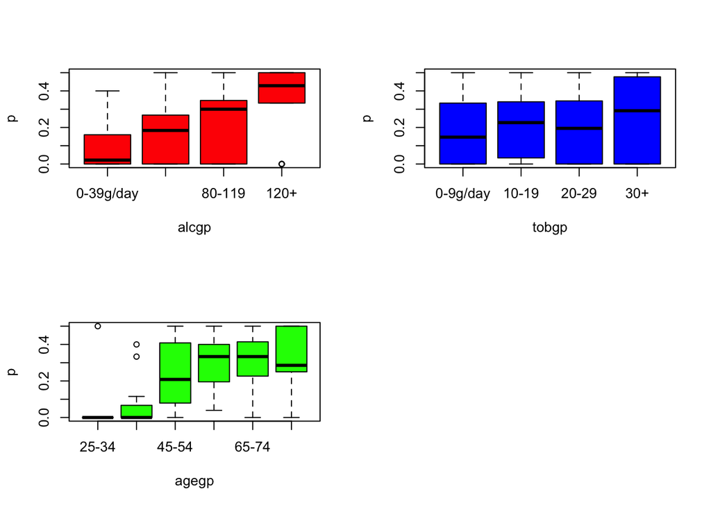

```r
# look at data as proportions
attach(esoph)
p <- ncases/(ncases + ncontrols)


# plot against explanatory variables
par(mfrow=c(2,2))
plot(p ~ alcgp, col = "red")
plot(p ~ tobgp, col = "blue")
plot(p ~ agegp, col = "green")
par(mfrow = c(1, 1))
```

```r
# combine similar levels
tob2 <- tobgp
levels(tob2)[2:3] <- "10-30"
levels(tob2)
```

```
## [1] "0-9g/day" "10-30"    "30+"
```

```r
age2 <- agegp
levels(age2)[4:6] <- "55+"
levels(age2)[1:2] <- "under45"
levels(age2)
```

```
## [1] "under45" "45-54"   "55+"
```

```r
model3 <- glm(cbind(ncases, ncontrols) ~ age2 * alcgp * tob2, family = binomial, data = esoph)
model4 <- step(model3)
```

```
## Start:  AIC=241.11
## cbind(ncases, ncontrols) ~ age2 * alcgp * tob2
```

```
##                   Df Deviance    AIC
## - age2:alcgp:tob2 12   30.807 226.29
## <none>                 21.631 241.11
```

```
##
## Step:  AIC=226.29
## cbind(ncases, ncontrols) ~ age2 + alcgp + tob2 + age2:alcgp +
##     age2:tob2 + alcgp:tob2
```

```
##              Df Deviance    AIC
## - alcgp:tob2  6   38.225 221.71
## - age2:tob2   4   38.021 225.50
## <none>            30.807 226.29
## - age2:alcgp  6   45.443 228.92
```

```
##
## Step:  AIC=221.71
## cbind(ncases, ncontrols) ~ age2 + alcgp + tob2 + age2:alcgp +
##     age2:tob2
##
##              Df Deviance    AIC
## - age2:tob2   4   44.677 220.16
## <none>            38.225 221.71
## - age2:alcgp  6   52.295 223.78
##
## Step:  AIC=220.16
## cbind(ncases, ncontrols) ~ age2 + alcgp + tob2 + age2:alcgp
##
##              Df Deviance    AIC
## <none>            44.677 220.16
## - age2:alcgp  6   60.388 223.87
## - tob2        2   52.991 224.47
```

```r
model5 <- update(model4, ~ .-age2:alcgp)
anova(model4, model5, test = "Chi")
```

```
## Analysis of Deviance Table
##
## Model 1: cbind(ncases, ncontrols) ~ age2 + alcgp + tob2 + age2:alcgp
## Model 2: cbind(ncases, ncontrols) ~ age2 + alcgp + tob2
##   Resid. Df Resid. Dev Df Deviance Pr(>Chi)
## 1        74     44.677
## 2        80     60.388 -6  -15.711  0.01539 *
## ---
## Signif. codes:  0 '***' 0.001 '**' 0.01 '*' 0.05 '.' 0.1 ' ' 1
```

```r
detach(esoph)
```